# Tensorflow Basic

- 출처: https://excelsior-cjh.tistory.com/151 [EXCELSIOR]

```python
from IPython.display import Image
from IPython.core.display import HTML
```

## 연산 그래프

그래프 노드(node)나 꼭지점(vertex)로 연결 되어 있는 개체(entity)의 집합 노드들은 연결(edge)을 통해 서로 연결

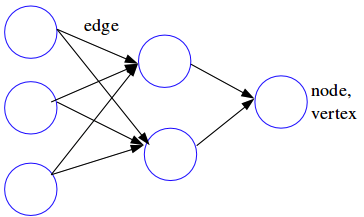

```python
Image(filename="graph-1.png", width="450")
```

- 데이터 흐름 그래프(DataFlow Graph)의 연결(edge)은 어떤 노드에서 다른 노드로 흘러가는(flow) 데이터의 방향을 정한다.
- 텐서플로에서 그래프의 각 노드는 "하나의 연산"을 나타내며, 입력값을 받아 다른 노드로 전달할 결과값을 출력

### 연산그래프의 장점

- 텐서플로어는 연산그래프의 의존성을 이용하여 연산을 최적화 함.
- 연산그래프의 의존관계

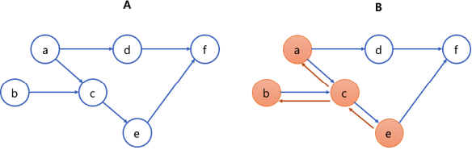

```python
Image(filename="comp-graph-dep.png", width="550")
```

## Tensorflow Basic

```python
# import 와 동시에 연산그래프가 생성, 만들어지는 모든 텐서들은 이 그래프에 자동으로 연결

import tensorflow as tf
```

```python
print(tf.__version__)
```

```
1.15.0
```

```python
# 상수정의
a = tf.constant(5)
b = tf.constant(2)
c = tf.constant(3)

# 연산정의
d = tf.multiply(a, b)  # a * b
e = tf.add(c, b)  # c + b
f = tf.subtract(d, e)  # d - e

# 세션을 생성
# with ... as 사용을 통해 sess.close() 를 자동으로 처리
with tf.Session() as sess:
    # A session을 실행
    print(sess.run(f))
```

```
5
```

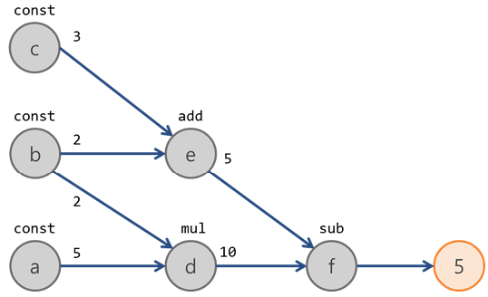

```python
Image(filename = "ex-1.png", width="500")
```

### Tensorflow operators

- tf.operator

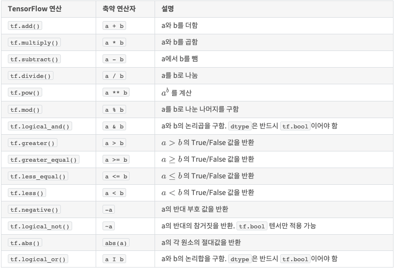

```python
Image(filename="tf-operators.png", width="900")
```

### Create and Run a session

1) 세션 선언 - 세션 객체 생성

- sess = tf.Session()
- sess = tf.InteractiveSession()

2) 세션 실행

- sess.run(텐서 혹은 연산)

3) 세션 종료

- sess.close()

```python
x = tf.placeholder(tf.float32)
y = tf.placeholder(tf.float32)
z = tf.multiply(x, y)

# Create a session as "sess" and run it by sess.run(tensorname)
sess = tf.Session()

# Session initialization
sess.run(tf.global_variables_initializer())

# Run a tensor, z, using session sess by feeding data
print(sess.run(z, feed_dict={x: [[3.,3.],[3.,3.]], y: [[5.,5.],[5.,5.]]}))

sess.close()
```

```
[[15. 15.]
 [15. 15.]]
```

```python
x = tf.constant([[3.,3.],[3.,3.]])
y = tf.constant([[5.,5.],[5.,5.]])
z = tf.multiply(x, y)

# Create a session as "sess" and run it by sess.run(tensorname)
with tf.Session() as sess:
    sess.run(tf.global_variables_initializer())
    print(sess.run(z))

    # Show x's values
    print(x.eval())
```

```
[[15. 15.]
 [15. 15.]]
[[3. 3.]
 [3. 3.]]
```

```python
x = tf.constant([[3.,3.],[3.,3.]])
y = tf.constant([[5.,5.],[5.,5.]])
z = tf.multiply(x, y)

# Create a session
sess = tf.Session()

# Session initialization
sess.run(tf.global_variables_initializer())

print(sess.run(z))  # z is running with session sess

# Show x's values
print(x.eval()) # Error due to no session for x
sess.close()
```

```
[[15. 15.]
 [15. 15.]]
```

[output not shown]

```python
x = tf.constant([[3.,3.],[3.,3.]])
y = tf.constant([[5.,5.],[5.,5.]])
z = tf.multiply(x, y)

sess = tf.InteractiveSession() # Create a default session
# Session initialization
sess.run(tf.global_variables_initializer())
print(sess.run(z))  # z is running with session sess
print(x.eval()) # Error due to no session for x
sess.close()
```

```
[[15. 15.]
 [15. 15.]]
[[3. 3.]
 [3. 3.]]
```

```python
# Create a and b variables of tensorflower
a = tf.placeholder("float")
b = tf.placeholder("float")

# Multiply a and b
y = tf.multiply(a,b)

# Create a session as "sess" with "with ... as"
# so that there is no need to call sess.close()

with tf.Session() as sess:
    # Use it when cpu 0 can dedicated to this session
    # with tf.devise("cpu:0")

    print(sess.run(y, feed_dict = {a:3, b:3}))
```

```
9.0
```

### Create a graph

```python
# Create a graph as g
g = tf.Graph()

# See default graph
print('default graph :', tf.get_default_graph())  # default graph

# See the graph object g
print('new graph :', g)  # new graph
```

```
default graph : <tensorflow.python.framework.ops.Graph object at 0x00000197FD8AA148>
new graph : <tensorflow.python.framework.ops.Graph object at 0x0000019780AFE108>
```

```python
a = tf.constant(5)  # a 노드 생성

print('a 노드가 g 그래프와 연결 되어 있나? :', a.graph is g)
print('a 노드가 기본 그래프와 연결 되어 있나? :', a.graph is tf.get_default_graph())
```

```
a 노드가 g 그래프와 연결 되어 있나? : False
a 노드가 기본 그래프와 연결 되어 있나? : True
```

### Connect a tensor to a graph

```python
g1 = tf.get_default_graph()
g2 = tf.Graph()

# g2 그래프가 기본 그래프인지 확인
print('g2가 기본 그래프인가? : ', g2 is tf.get_default_graph())

# with 구문을 이용한 g2를 기본 그래프로 지정하기
with g2.as_default():
  print('g2가 기본 그래프인가? : ', g2 is tf.get_default_graph())

# with 구문이 끝났으므로g2를 기본 그래프에서 해제
print('g2가 기본 그래프인가? : ', g2 is tf.get_default_graph())
```

```
g2가 기본 그래프인가? :  False
g2가 기본 그래프인가? :  True
g2가 기본 그래프인가? :  False
```

### Fetch a tensor

```python
# 상수 정의
a = tf.constant(5)
b = tf.constant(2)
c = tf.constant(3)

# 연산정의
d = tf.multiply(a, b)  # a * b
e = tf.add(c, b)  # c + b
f = tf.subtract(d, e)  # d - e

with tf.Session() as sess:
    fetches = [a, b, c, d, e, f]
    outs = sess.run(fetches)

print("outs = {}".format(outs))
print(type(outs[0]))
```

```
outs = [5, 2, 3, 10, 5, 5]
<class 'numpy.int32'>
```

```python
a = tf.constant(5)
g2 = tf.Graph()
print('a 노드가 g2 그래프와 연결 되어 있나? :', a.graph is g2)

with g2.as_default():
    # 상수 정의
    a = tf.constant(5)
    b = tf.constant(2)
    c = tf.constant(3)

    # 연산정의
    d = tf.multiply(a, b)  # a * b
    e = tf.add(c, b)  # c + b
    f = tf.subtract(d, e)  # d - e

    with tf.Session() as sess:
        fetches = [a, b, c, d, e, f]
        outs = sess.run(fetches)
        print("outs = {}".format(outs))
    print(type(outs[0]))
    print('a 노드가 g2 그래프와 연결 되어 있나? :', a.graph is g2)

print('a 노드가 g2 그래프와 연결 되어 있나? :', a.graph is g2)
```

```
a 노드가 g2 그래프와 연결 되어 있나? : False
outs = [5, 2, 3, 10, 5, 5]
<class 'numpy.int32'>
a 노드가 g2 그래프와 연결 되어 있나? : True
a 노드가 g2 그래프와 연결 되어 있나? : True
```

## Flow of Tensors

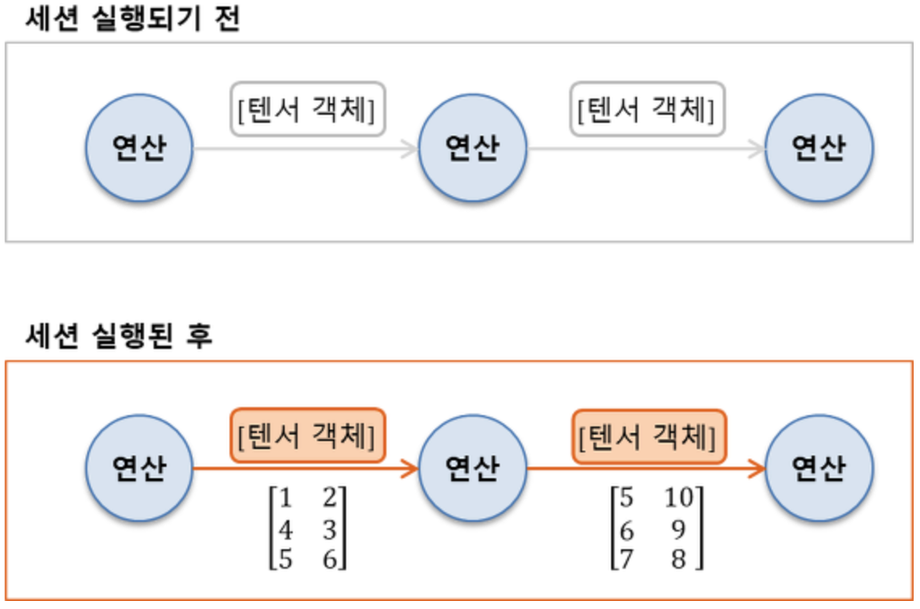

```python
Image(filename="tensorflow-1.png",width=600)
```

- tf.add(), tf.multiply() 등으로 그래프에서 노드(node)를 만들 때, 실제로는 연산 인스턴스가 생성된다. 생성된 연산(인스턴스)들은 그래프가 실행되기 전까지는 연산한 값을 반환하지 않고, 계산된 결과를 다른 노드로 전달할 수 있는 핸들(handle), 즉 흐름(flow)으로 참조
- 이러한 핸들은 그래프에서 엣지(edge)라고 할 수 있으며, 텐서 객체(Tensor object)라고 함
- 텐서플로는 모든 구성 요소가 담긴 그래프의 골격을 먼저 만들도록 설계. 이 시점에는 실제 텐서(데이터)는 흐르지 않으며 연산 또한 수행되지 않는다. 세션(Session)이 실행되면 그래프에 텐서가 입력되고 연산이 수행

```python
# 텐서 인스턴스 및 핸들 생성
tensor_a = tf.constant([[1, 2], [3, 4]])

print('Session이 실행되기 전 :', tensor_a)

# 세션 생성
sess = tf.Session()

# 세션 실행
out = sess.run(tensor_a)
print('Session이 실행된 후 :\n', out)

# 텐서플로의 텐서 객체의 속성에 유의 name, shape, dtype

sess.close()
```

```
Session이 실행되기 전 : Tensor("Const_14:0", shape=(2, 2), dtype=int32)
Session이 실행된 후 :
 [[1 2]
 [3 4]]
```

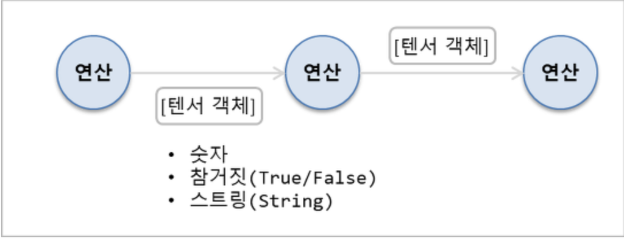

```python
Image(filename="tensor-type-1.png",width=900)
```

- 그래프를 통해 전달되는 데이터의 기본 단위는 숫자, 참거짓값(True, False), 스트링 임
- tensor_a = tf.constant([[1, 2], [3, 4]])는 데이터타입(dtype)을 정의하지 않았기 때문에 텐서플로가 자동으로 int32로 데이터 타입을 추측
- 혹은 텐서 객체를 만들때 데이터 타임을 정의할 수 있음

```python
tensor_a = tf.constant([[1, 2], [3, 4]], dtype=tf.float64)
print(tensor_a)
print(tensor_a.dtype)
```

```
Tensor("Const_15:0", shape=(2, 2), dtype=float64)
<dtype: 'float64'>
```

## Type Casting

### Type

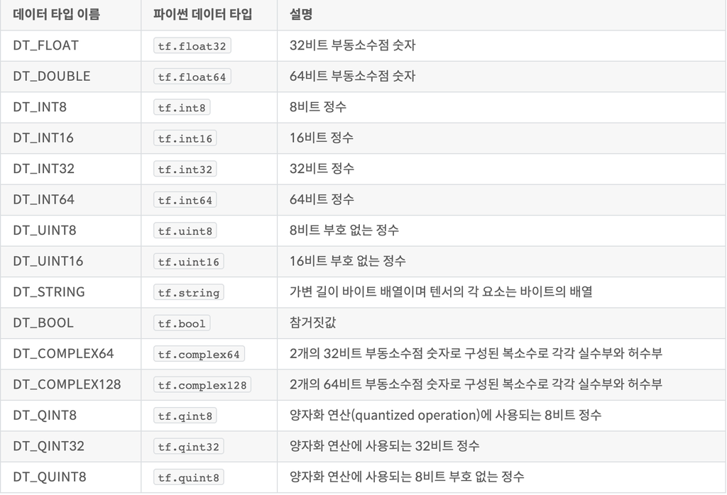

```python
Image(filename="tensor-type-2.png",width=900)
```

### Array

#### Tensor:

1) 그래프에서 연산의 결과, 파이썬 API에서 사용하는 객체의 이름

2) 차원 배열을 가리키는 수학 용어.

- 1 *1 텐서는 스칼라, 1* n 텐서는 벡터, n *n 텐서는 행렬, n* n * n 텐서는 3차원 배열
- 텐서플로에서는 다차원 배열, 벡터, 행렬, 스칼라 등을 그래프에서 전달되는 모든 데이터를 텐서
- 파이썬의 자료형인 리스트(list)나 NumPy의 배열을 사용하여 텐서를 초기화 가능

```python
import numpy as np
import tensorflow as tf

c = tf.constant([[1, 2, 3],
               [4, 5, 6]])
print('Python List input :', c.get_shape())
c = tf.constant(np.array([
                [[1, 2, 3],
                 [4, 5, 6]],

                [[1, 1, 1],
                 [2, 2, 2]]
              ]))
print("3d NumPy array input :", c.get_shape())
```

```
Python List input : (2, 3)
3d NumPy array input : (2, 2, 3)
```

### Random Number Generation

```python
import matplotlib
import matplotlib.pyplot as plt
from IPython.core.pylabtools import figsize

# matplotlib.rc('font', family='NanumGothic')  # Linumx
matplotlib.rc('font', family='AppleGothic')  # Mac
```

```python
# Normal Distribution

sess = tf.InteractiveSession()

# === Normal and Truncated normal distribution ===
mean, std = 0, 1
x_normal = tf.random_normal((1, 50000), mean, std).eval()  # shape = (1, 50000)
x_truncated = tf.truncated_normal((1, 50000), mean, std).eval()

# === Uniform distribution ===
minval, maxval = -2, 2
x_uniform = tf.random_uniform((1, 50000), minval, maxval).eval()

sess.close()
```

[output not shown]

[figure not shown]

```python
# matplotlib 설정 부분
def simpleaxis(ax):
    ax.spines['top'].set_visible(False)
    ax.spines['right'].set_visible(False)
    ax.get_xaxis().tick_bottom()
    ax.get_yaxis().tick_left()
    ax.tick_params(axis='both', which='major', labelsize=15)

def get_axis_limits(ax, scale=.8):
    return ax.get_xlim()[1]*scale, ax.get_ylim()[1]*scale

f,axarr = plt.subplots(1,3,figsize=[15,4],sharey=True)
titles = ['정규분포','절단정규분포','균등분포']

for i,x in enumerate([x_normal,x_truncated,x_uniform]):
    ax = axarr[i]
    ax.hist(x[0], bins=100, alpha=0.4)
    ax.set_title(titles[i], fontsize=20)
    ax.set_xlabel('Values', fontsize=20)
    ax.set_xlim([-5, 5])
    ax.set_ylim([0, 1800])

    simpleaxis(ax)

axarr[0].set_ylabel('Frequency', fontsize=20)
plt.suptitle('난수 생성', fontsize=30, y=1.15)

for ax,letter in zip(axarr,['A','B','C']):
    simpleaxis(ax)
    ax.annotate(letter, xy=get_axis_limits(ax),fontsize=35)

plt.tight_layout()
```

### Interactive Session

- 대화형

```python
sess = tf.InteractiveSession()

# 0.0 ~ 4.0 을 같은 간격으로 5개 값 생성
c = tf.linspace(0.0, 4.0, 5)

print("The content of 'c': \n {}\n".format(c.eval()))
sess.close()
```

```
The content of 'c':
 [0. 1. 2. 3. 4.]
```

### Initialization functions

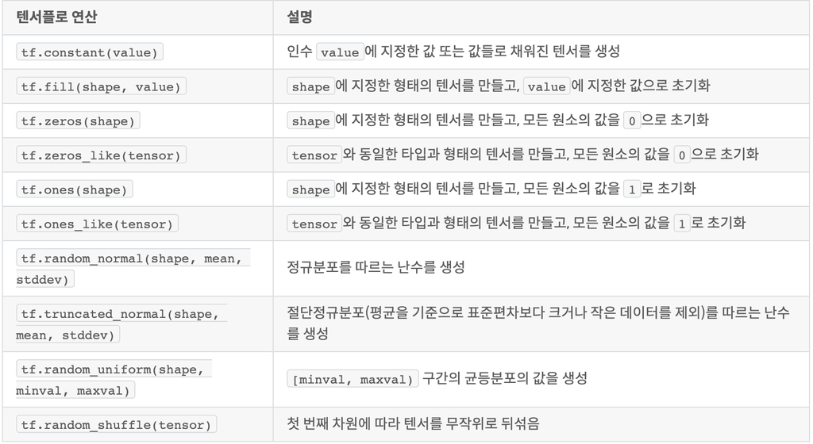

```python
Image(filename = "tensor-init-fnc-1.png", width=900)
```

### Matrix Multiplication

```python
A = tf.constant([[1, 2],
               [3, 4]])

B = tf.constant([[4, 3],
               [2, 1]])

AB = tf.matmul(A, B)

tf.InteractiveSession()
print('matmul restlt:\n {}'.format(AB.eval()))
sess.close()
```

```
matmul restlt:
 [[ 8  5]
 [20 13]]
```

## Name

- 텐서플로의 각 텐서 객체는 고유의 이름 가짐.
- 텐서 객체의 인자에 name을 사용해 이름을 지정할 수 있으며 .name속성을 통해 확인

```python
c1 = tf.constant(4, dtype=tf.float64, name='c')
c2 = tf.constant(4, dtype=tf.int32, name='c')

# 두 텐서에 같은 이름을 부여했지만 자동으로 다른 이름이 지정
print(c1.name)
print(c2.name)
```

```
c:0
c_1:0
```

### Name scope

- 복잡한 그래프를 처리해야 하는 경우 이를 쉽게 추적하고 관리하기 위해서 노드를 이름별로 그룹화
- with구문과 tf.name_scope('prefix_name')를 사용하면 이름 스코프를 사용

```python
c1 = tf.constant(4, dtype=tf.float64, name='c')
with tf.name_scope("prefix_name"):
    c2 = tf.constant(4, dtype=tf.int32, name='c')
    c3 = tf.constant(4, dtype=tf.float64, name='c')

print('c1.name >>', c1.name)
print('c2.name >>', c2.name)
print('c3.name >>', c3.name)
```

```
c1.name >> c_2:0
c2.name >> prefix_name/c:0
c3.name >> prefix_name/c_1:0
```

## 변수, 플레이스홀더, 간단한 최적화

### 변수

- 딥러닝 학습에서 최적화 과정은 주어진 모델의 매개변수(parameters) 즉, 가중치(및 편향)를 조정하는 것
- 이러한 최적화 과정을 위핸 텐서플러어는 변수(Variable) 라는 객체를 사용
- 변수는 세션이 실행될 때 마다 그래프에서 고정된 상태를 유지. 그렇기 때문에 변수는 최적화를 위한 반복 과정에서 현재의 변수가 다음 반복 과정에 영향을 줌.

1) tf.Variable()함수를 사용해 변수를 만들고 어떤 값으로 초기화할지를 정의한다.

2) tf.global_variables_initializer() 메소드를 사용하여 세션에 초기화 연산을 수행해야 하며, 변수에 메모리를 할당하고 초기값을 설정하는 역할을 한다.

```python
init_val = tf.random_normal((1, 5), 0, 1)

var = tf.Variable(init_val, name='var')
print("pre run: \n{}".format(var))

init = tf.global_variables_initializer()
with tf.Session() as sess:
    sess.run(init)
    post_var = sess.run(var)

print('\npost run: \n{}'.format(post_var))
```

```
pre run:
<tf.Variable 'var:0' shape=(1, 5) dtype=float32_ref>

post run:
[[-1.9352415  1.0734    -0.3639494  1.9299507 -0.7866945]]
```

## Placeholder

- 플레이스홀더(placeholder): 입력값을 넣어주기 위한 텐서플로어의 변수
- 플레이스홀더는 데이터를 입력받는 비어있는 변수. 먼저 그래프를 구성하고, 그 그래프가 실행되는 시점에 입력 데이터를 넣어주는 데 사용
- 플레이스홀더는 shape 인수를 유동적으로 지정. 예를 들어, None으로 지정되면 이 플레이스홀더는 모든 크기의 데이터를 받을 수 있움.
- 주로 배치단위(batch size)의 샘플 데이터 개수에 해당 되는 부분(데이터의 행)은 None을 사용하고, 데이터 Feature의 길이(데이터의 열)는 고정된 값을 사용
- E.g. ph = tf.placeholder(tf.float32, shape=(None, 10))
- 그래프의 실행 단계에서 플래스홀더는 반드시 입력값이 지정되어야 함.
- E.g. sess.run(s, feed_dict={ph: data})

```python
x_data = np.random.randn(5, 10)
w_data = np.random.randn(10, 1)

with tf.Graph().as_default():
    x = tf.placeholder(tf.float32, shape=(5, 10))
    w = tf.placeholder(tf.float32, shape=(10, 1))
    b = tf.fill((5, 1), -1.)
    xw = tf.matmul(x, w)

    xwb = xw + b
    s = tf.reduce_max(xwb)

    with tf.Session() as sess:
        outs = sess.run(s, feed_dict={x: x_data, w: w_data})

    print("outs = {}".format(outs))
```

```
outs = 4.349737644195557
```

### 최적화

- 모델을 최적화하기 위해서는 모델의 성능을 평가할 수 있는 척도가 필요
- 모델이 예측한 값과 관측값 사이의 불일치 정도를 확인하려면 '거리'를 반영하는 척도가 필요.
- 이러한 거리를 손실(loss)함수라고 함
- 이 함수의 값을 최소화하는 파라미터(가중치, 편향)을 찾아내는 것이 딥러닝 모델을 최적화하는 것.
- 보통 손실함수는 실제와 이론을 모두 구려해 가장 적절한 것을 선택하므로 정확한 손실함수는 존재하지 않음

### 평균제곱오차 (Mean Square Error)

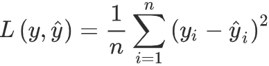

```python
Image(filename="mse-1.png")
```

loss = tf.reduce_mean(tf.square(y_true - y_pred))

or

loss = tf.losses.mean_squared_error(y_true, y_pred)

### 교차엔트로피(Cross Entropy)

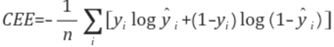

```python
Image(filename="cee-1.png")
```

loss = tf.nn.sigmoid_cross_entropy_with_logits(labels=y_true, logits_y_pred)

loss = tf.reduce_mean(loss)

### 경사 하강법(Gradient Descent) 최적화 함수

- 손실함수를 최소화하는 다양한 최적화 알고리즘

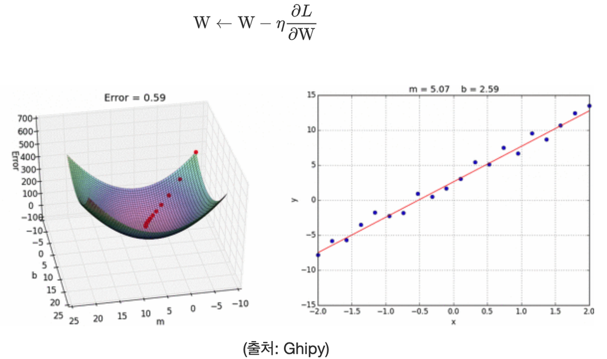

```python
Image(filename="gradientdescent-1.png")
```

optimizer = tf.train.GradientDescentOptimizer(learning_rate)

train = optimizer.minimize(loss)

### 예제 1:Linear Regression

- 가우시안 노이즈를 추가한 입력 벡터 x일때 가중치 w와 편향값 b를 찾아내는 문제

```python
import matplotlib.pyplot as plt

# === Create data and simulate results ===

# shape = (2000, 3)인 정규분포(mu=0, sigma=1)
x_data = np.random.randn(2000, 3)
w_real = [0.3, 0.5, 0.1]
b_real = -0.2

# 가우시안 노이즈
noise = np.random.randn(1, 2000) * 0.1
y_data = np.matmul(w_real, x_data.T) + b_real + noise
```

```python
NUM_STEPS = 10
g = tf.Graph()
wb_ = []
with g.as_default():
    x = tf.placeholder(tf.float32, shape=[None, 3])
    y_true = tf.placeholder(tf.float32, shape=None)

    with tf.name_scope('inference') as scope:
        w = tf.Variable([[0, 0, 0]], dtype=tf.float32, name='weights')
        b = tf.Variable(0, dtype=tf.float32, name='bias')
        y_pred = tf.matmul(w, tf.transpose(x)) + b

    with tf.name_scope('loss') as scope:
        # loss = tf.reduce_mean(tf.square(y_true - y_pred))  # MSE
        loss = tf.losses.mean_squared_error(y_true, y_pred)

    with tf.name_scope('train') as scope:
        learning_rate = 0.5
        optimizer = tf.train.GradientDescentOptimizer(learning_rate)
        train = optimizer.minimize(loss)

    # Before starting, initialize the variables.
    init = tf.global_variables_initializer()
    with tf.Session() as sess:
        sess.run(init)
        for step in range(NUM_STEPS):
            sess.run(train, feed_dict={x: x_data, y_true: y_data})
            if step % 5 == 0:
                print(step, sess.run([w, b]))
                wb_.append(sess.run([w, b]))
        print(10, sess.run([w, b]))
```

```
WARNING:tensorflow:From C:\ProgramData\Anaconda3\lib\site-packages\tensorflow_core\python\ops\losses\losses_impl.py:121: where (from tensorflow.python.ops.array_ops) is deprecated and will be removed in a future version.
Instructions for updating:
Use tf.where in 2.0, which has the same broadcast rule as np.where
0 [array([[0.29360366, 0.48233208, 0.09198429]], dtype=float32), -0.1897413]
5 [array([[0.29685304, 0.50270176, 0.09917224]], dtype=float32), -0.19947708]
10 [array([[0.29685304, 0.50270176, 0.09917224]], dtype=float32), -0.19947708]
```

### 예제 2: Logistic Regression

```python
N = 20000

def sigmoid(x):
    return 1 / (1 + np.exp(-x))

# === Create data and simulate results ===
x_data = np.random.randn(N, 3)
w_real = [0.3, 0.5, 0.1]
b_real = -0.2

wxb = np.matmul(w_real, x_data.T) + b_real

y_data_pre_noise = sigmoid(wxb)  # 이진화 전
y_data = np.random.binomial(1, y_data_pre_noise)  # 이진화 후

y_data
```

```
array([0, 1, 1, ..., 0, 1, 1])
```

```python
NUM_STEPS = 100

g = tf.Graph()
wb_ = []
with g.as_default():
    x = tf.placeholder(tf.float32, shape=[None, 3])
    y_true = tf.placeholder(tf.float32, shape=None)

    with tf.name_scope('inference') as scope:
        w = tf.Variable([[0, 0, 0]], dtype=tf.float32, name='weights')
        b = tf.Variable(0, dtype=tf.float32, name='bias')
        y_pred = tf.matmul(w, tf.transpose(x)) + b

    with tf.name_scope('loss') as scope:
        loss =tf.nn.sigmoid_cross_entropy_with_logits(labels=y_true, logits=y_pred)
        loss = tf.reduce_mean(loss)

    with tf.name_scope('train') as scope:
        learning_rate = 0.5
        optimizer = tf.train.GradientDescentOptimizer(learning_rate)
        train = optimizer.minimize(loss)

    # Before starting, initialize the variables
    init = tf.global_variables_initializer()
    with tf.Session() as sess:
        sess.run(init)
        for step in range(NUM_STEPS):
            sess.run(train, feed_dict={x: x_data, y_true: y_data})
            if step % 10 == 0:
                print(step, sess.run([w, b]))
                wb_.append(sess.run([w, b]))

        print(100, sess.run([w, b]))
```

```
0 [array([[0.03335653, 0.05764157, 0.01197011]], dtype=float32), -0.024799984]
10 [array([[0.20841376, 0.35987175, 0.07453515]], dtype=float32), -0.15480708]
20 [array([[0.2619057 , 0.4519944 , 0.09345446]], dtype=float32), -0.1941371]
30 [array([[0.28004602, 0.483157  , 0.09980593]], dtype=float32), -0.20728348]
40 [array([[0.2864301 , 0.4941003 , 0.10202187]], dtype=float32), -0.21184719]
50 [array([[0.28870526, 0.49799347, 0.10280588]], dtype=float32), -0.2134547]
60 [array([[0.2895195 , 0.49938473, 0.1030848 ]], dtype=float32), -0.21402441]
70 [array([[0.28981125, 0.4998827 , 0.10318425]], dtype=float32), -0.21422693]
80 [array([[0.2899158 , 0.50006104, 0.10321973]], dtype=float32), -0.21429905]
90 [array([[0.28995326, 0.50012493, 0.10323241]], dtype=float32), -0.21432477]
100 [array([[0.28996587, 0.5001464 , 0.10323667]], dtype=float32), -0.21433342]
```